# MPG by Transmission

Scott Brenstuhl

##### Executive Summary

Using the 1974 Motor Trend data we look into if shifting using manual transmission actually gets better mpg as is comonly believed. By compairing the average mpg for each transmission type, we find that manuals get 7.24 more miles per gallon. However once we account for many of the addional variables that contribute to mpg, the mpg advantage of manual transmissions shrinks to an average of 2.94 more mpg. Still, we are able to confirm having a manual transmission will get you better mpg.

##### Exploritory analysis

By making a boxplot of MPH and transmission (Fig 1) we can see that at first glance manuals tend to have better MPG. We can then make a matrix of plots to see how the values we are interested in interact (Fig 2).

```
## Source: local data frame [2 x 2]
##
##   am mean(mpg)
## 1  0  17.14737
## 2  1  24.39231
```

By taking the average mpg for both automatic trasnmission and manual transmission we can see that the average manual has 7.24 higher miles per gallon.

```
## [1] "p-value: 0.00137363833307103"
```

We then run a t-test of the two and reject the null hypothesis with a p-value of .00137, showing that the difference between transmissions is significant.

##### Fitting Models

```
##              Estimate Std. Error   t value     Pr(>|t|)
## (Intercept) 17.147368   1.124603 15.247492 1.133983e-15
## factor(am)1  7.244939   1.764422  4.106127 2.850207e-04
```

```
## [1] "r squared: 0.359798943425465"
```

By fitting a model for just the the mpg predicted by the transmission type, we see that it does offer a statistically significant improvement from just average mpg. However this only explains 36% of the variance so we can’t confidently draw any conclusions from it.

```
##       mpg        wt       cyl      disp        hp      drat        vs
## 1.0000000 0.8676594 0.8521620 0.8475514 0.7761684 0.6811719 0.6640389
##        am      carb      gear      qsec
## 0.5998324 0.5509251 0.4802848 0.4186840
```

Luckly we can run a function to quickly go throught the confounders and pick the best model, which happens to show that transmission is significant:

```
## lm(formula = mpg ~ wt + qsec + am, data = mtcars)
```

```
## [1] "r squared: 0.849663556361707"
```

By looking at the full corelation grid (Fig 4, visualized: Fig 2) we can see that many of the variables strongly affect one another so it makes sense that qsec is able to represent many of the variables in our data. With this model allowing us to address transmission, explaining 85% of variation is great.

##### Residual Plot and Diagnostics

```r
sort(hatvalues(slml),decreasing = TRUE)[1:5]
```

```
##            Merc 230 Lincoln Continental   Chrysler Imperial
##           0.2970422           0.2642151           0.2296338
##  Cadillac Fleetwood       Maserati Bora
##           0.2270069           0.1909815
```

We check the leverage of our data by looking at the highest hat values and see that we have a couple of cars with over two times the mean hat value of .125. However when we look at Fig 5, they dont appear to be anything to worry about. We can also see that there are not any obvious trends in the fitted vs residual or leverage plots, and the Normal Q-Q plot shows that the residuals are fairly normally distributed.

##### Conclusions

```
##              Estimate Std. Error   t value     Pr(>|t|)
## (Intercept)  9.617781  6.9595930  1.381946 1.779152e-01
## wt          -3.916504  0.7112016 -5.506882 6.952711e-06
## qsec         1.225886  0.2886696  4.246676 2.161737e-04
## am           2.935837  1.4109045  2.080819 4.671551e-02
```

While we have some uncertainty since there are not identical models with each transmission, we can feel fairly confident in our conclusions since our model explains 85% of the variability. With p-value .0467 < .05 we reject the null hypothesis and accept that manual transmissions have an average of 2.94 better mpg than automatic transmissions.

# Appendix

Fig 1:

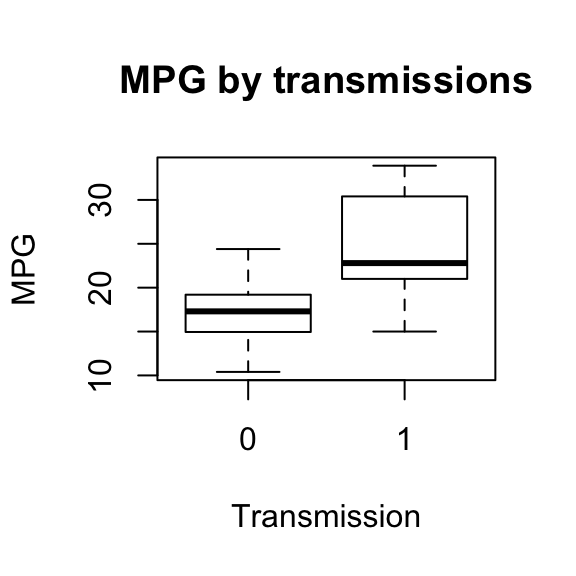

Fig 2:

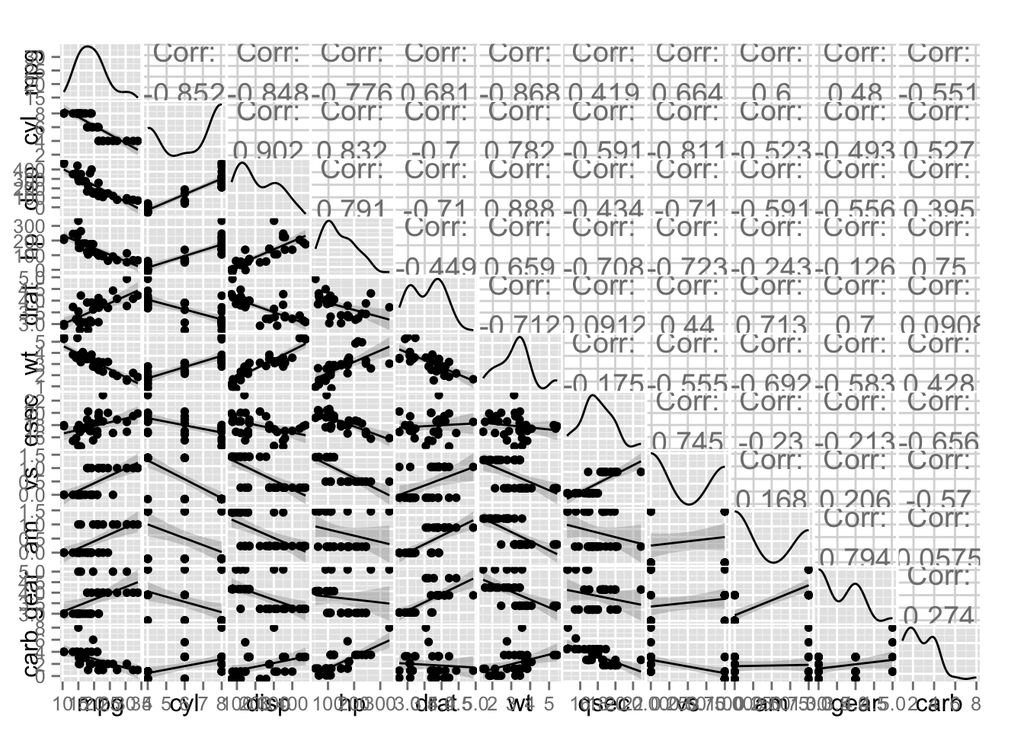

Fig 3:

```
## Analysis of Variance Table
##
## Model 1: mpg ~ factor(am)
## Model 2: mpg ~ factor(am) + wt
## Model 3: mpg ~ factor(am) + wt + cyl
## Model 4: mpg ~ factor(am) + wt + cyl * hp
##   Res.Df    RSS Df Sum of Sq       F    Pr(>F)
## 1     30 720.90
## 2     29 278.32  1    442.58 88.2171 7.692e-10 ***
## 3     28 191.05  1     87.27 17.3957 0.0002991 ***
## 4     26 130.44  2     60.61  6.0403 0.0070064 **
## ---
## Signif. codes:  0 '***' 0.001 '**' 0.01 '*' 0.05 '.' 0.1 ' ' 1
```

```
##                Estimate  Std. Error   t value     Pr(>|t|)
## (Intercept) 49.48140970 5.498418858  8.999207 1.816772e-09
## factor(am)1  1.32173163 1.287637097  1.026478 3.141219e-01
## wt          -2.61933283 0.821100145 -3.190028 3.692863e-03
## cyl         -2.53843061 0.823694841 -3.081761 4.821502e-03
## hp          -0.16751165 0.052209952 -3.208424 3.528272e-03
## cyl:hp       0.01865876 0.006644811  2.808020 9.330036e-03
```

```
## [1] "r squared: 0.884161542159935"
```

Fig 4:

```
##             mpg        cyl       disp         hp        drat         wt
## mpg   1.0000000 -0.8521620 -0.8475514 -0.7761684  0.68117191 -0.8676594
## cyl  -0.8521620  1.0000000  0.9020329  0.8324475 -0.69993811  0.7824958
## disp -0.8475514  0.9020329  1.0000000  0.7909486 -0.71021393  0.8879799
## hp   -0.7761684  0.8324475  0.7909486  1.0000000 -0.44875912  0.6587479
## drat  0.6811719 -0.6999381 -0.7102139 -0.4487591  1.00000000 -0.7124406
## wt   -0.8676594  0.7824958  0.8879799  0.6587479 -0.71244065  1.0000000
## qsec  0.4186840 -0.5912421 -0.4336979 -0.7082234  0.09120476 -0.1747159
## vs    0.6640389 -0.8108118 -0.7104159 -0.7230967  0.44027846 -0.5549157
## am    0.5998324 -0.5226070 -0.5912270 -0.2432043  0.71271113 -0.6924953
## gear  0.4802848 -0.4926866 -0.5555692 -0.1257043  0.69961013 -0.5832870
## carb -0.5509251  0.5269883  0.3949769  0.7498125 -0.09078980  0.4276059
##             qsec         vs          am       gear        carb
## mpg   0.41868403  0.6640389  0.59983243  0.4802848 -0.55092507
## cyl  -0.59124207 -0.8108118 -0.52260705 -0.4926866  0.52698829
## disp -0.43369788 -0.7104159 -0.59122704 -0.5555692  0.39497686
## hp   -0.70822339 -0.7230967 -0.24320426 -0.1257043  0.74981247
## drat  0.09120476  0.4402785  0.71271113  0.6996101 -0.09078980
## wt   -0.17471588 -0.5549157 -0.69249526 -0.5832870  0.42760594
## qsec  1.00000000  0.7445354 -0.22986086 -0.2126822 -0.65624923
## vs    0.74453544  1.0000000  0.16834512  0.2060233 -0.56960714
## am   -0.22986086  0.1683451  1.00000000  0.7940588  0.05753435
## gear -0.21268223  0.2060233  0.79405876  1.0000000  0.27407284
## carb -0.65624923 -0.5696071  0.05753435  0.2740728  1.00000000
```

Fig 5:

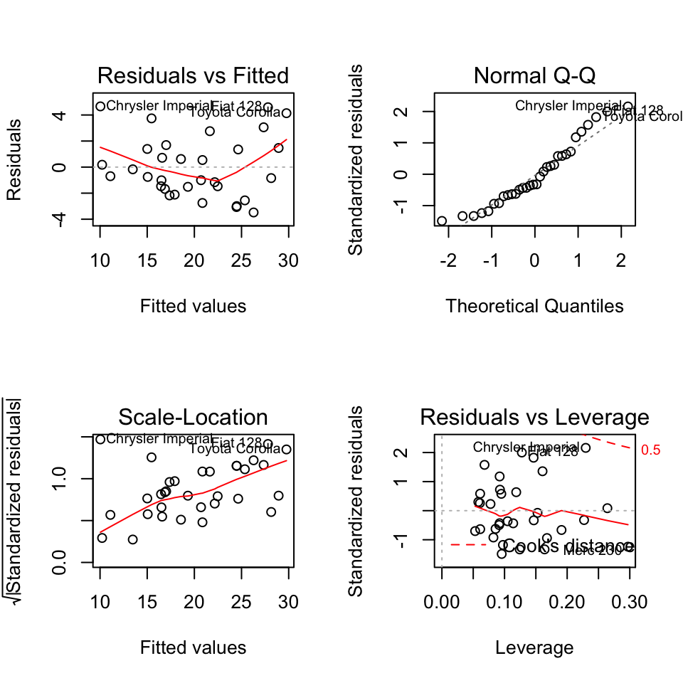